# Интернет-магазин "Крупный": A/B-тестирование гипотез.

# Table of Contents

## Общее описание проекта и исходные данные

Аналитики "Крупного" интернет-магазина совместно с отделом маркетинга подготовили список гипотез для увеличения выручки.

**Задача исследования:**

приоритизировать гипотезы, запустить A/B-тест и проанализировать его результаты.

```python
import pandas as pd
import scipy.stats as stats
import datetime as dt
import numpy as np
import matplotlib.pyplot as plt
from matplotlib.ticker import MultipleLocator
```

```python
import warnings
warnings.filterwarnings(action='ignore')
```

## Часть 1. Приоритизация гипотез.

```python
hypothesis
```

|  | Hypothesis | Reach | Impact | Confidence | Efforts |
| --- | --- | --- | --- | --- | --- |
| 0 | Добавить два новых канала привлечения трафика,... | 3 | 10 | 8 | 6 |
| 1 | Запустить собственную службу доставки, что сок... | 2 | 5 | 4 | 10 |
| 2 | Добавить блоки рекомендаций товаров на сайт ин... | 8 | 3 | 7 | 3 |
| 3 | Изменить структура категорий, что увеличит кон... | 8 | 3 | 3 | 8 |
| 4 | Изменить цвет фона главной страницы, чтобы уве... | 3 | 1 | 1 | 1 |
| 5 | Добавить страницу отзывов клиентов о магазине,... | 3 | 2 | 2 | 3 |
| 6 | Показать на главной странице баннеры с актуаль... | 5 | 3 | 8 | 3 |
| 7 | Добавить форму подписки на все основные страни... | 10 | 7 | 8 | 5 |
| 8 | Запустить акцию, дающую скидку на товар в день... | 1 | 9 | 9 | 5 |

```python
hypothesis.columns = [x.lower().replace(' ', '_') for x in hypothesis.columns.values]
```

```python
hypothesis.info()
```

```
<class 'pandas.core.frame.DataFrame'>
RangeIndex: 9 entries, 0 to 8
Data columns (total 5 columns):
 #   Column      Non-Null Count  Dtype
---  ------      --------------  -----
 0   hypothesis  9 non-null      object
 1   reach       9 non-null      int64
 2   impact      9 non-null      int64
 3   confidence  9 non-null      int64
 4   efforts     9 non-null      int64
dtypes: int64(4), object(1)
memory usage: 488.0+ bytes
```

```python
hypothesis.describe()
```

|  | reach | impact | confidence | efforts |
| --- | --- | --- | --- | --- |
| count | 9.000000 | 9.000000 | 9.000000 | 9.000000 |
| mean | 4.777778 | 4.777778 | 5.555556 | 4.888889 |
| std | 3.153481 | 3.192874 | 3.045944 | 2.803767 |
| min | 1.000000 | 1.000000 | 1.000000 | 1.000000 |
| 25% | 3.000000 | 3.000000 | 3.000000 | 3.000000 |
| 50% | 3.000000 | 3.000000 | 7.000000 | 5.000000 |
| 75% | 8.000000 | 7.000000 | 8.000000 | 6.000000 |
| max | 10.000000 | 10.000000 | 9.000000 | 10.000000 |

```python
hypothesis['hypothesis'].tolist()
```

```
['Добавить два новых канала привлечения трафика, что позволит привлекать на 30% больше пользователей',
 'Запустить собственную службу доставки, что сократит срок доставки заказов',
 'Добавить блоки рекомендаций товаров на сайт интернет магазина, чтобы повысить конверсию и средний чек заказа',
 'Изменить структура категорий, что увеличит конверсию, т.к. пользователи быстрее найдут нужный товар',
 'Изменить цвет фона главной страницы, чтобы увеличить вовлеченность пользователей',
 'Добавить страницу отзывов клиентов о магазине, что позволит увеличить количество заказов',
 'Показать на главной странице баннеры с актуальными акциями и распродажами, чтобы увеличить конверсию',
 'Добавить форму подписки на все основные страницы, чтобы собрать базу клиентов для email-рассылок',
 'Запустить акцию, дающую скидку на товар в день рождения']
```

**Промежуточные выводы:**

- данные соответствуют описанию;
- данные готовы для исследования.

### Фреймворк ICE.

```python
hypothesis['ice'] = hypothesis['impact'] * hypothesis['confidence'] / hypothesis['efforts']
hypothesis.sort_values(by='ice', ascending=False).style.format({'ice':'{:.2f}'})
```

|  | hypothesis | reach | impact | confidence | efforts | ice |
| --- | --- | --- | --- | --- | --- | --- |
| 8 | Запустить акцию, дающую скидку на товар в день рождения | 1 | 9 | 9 | 5 | 16.20 |
| 0 | Добавить два новых канала привлечения трафика, что позволит привлекать на 30% больше пользователей | 3 | 10 | 8 | 6 | 13.33 |
| 7 | Добавить форму подписки на все основные страницы, чтобы собрать базу клиентов для email-рассылок | 10 | 7 | 8 | 5 | 11.20 |
| 6 | Показать на главной странице баннеры с актуальными акциями и распродажами, чтобы увеличить конверсию | 5 | 3 | 8 | 3 | 8.00 |
| 2 | Добавить блоки рекомендаций товаров на сайт интернет магазина, чтобы повысить конверсию и средний чек заказа | 8 | 3 | 7 | 3 | 7.00 |
| 1 | Запустить собственную службу доставки, что сократит срок доставки заказов | 2 | 5 | 4 | 10 | 2.00 |
| 5 | Добавить страницу отзывов клиентов о магазине, что позволит увеличить количество заказов | 3 | 2 | 2 | 3 | 1.33 |
| 3 | Изменить структура категорий, что увеличит конверсию, т.к. пользователи быстрее найдут нужный товар | 8 | 3 | 3 | 8 | 1.12 |
| 4 | Изменить цвет фона главной страницы, чтобы увеличить вовлеченность пользователей | 3 | 1 | 1 | 1 | 1.00 |

Согласно фреймворка ICE наиболее приоритетной гипотезой является:

`Запустить акцию, дающую скидку на товар в день рождения`.

Этот результат достигнут за счёт сильного влияния на пользователей, высокой уверенности в показателях гипотезы и средней трудоёмкости проверки.

### Фреймворк RICE.

```python
hypothesis['rice'] = hypothesis['reach'] * hypothesis['impact'] * hypothesis['confidence'] / hypothesis['efforts']
hypothesis.sort_values(by='rice', ascending=False).style.format({'ice':'{:.2f}', 'rice':'{:.2f}'})
```

|  | hypothesis | reach | impact | confidence | efforts | ice | rice |
| --- | --- | --- | --- | --- | --- | --- | --- |
| 7 | Добавить форму подписки на все основные страницы, чтобы собрать базу клиентов для email-рассылок | 10 | 7 | 8 | 5 | 11.20 | 112.00 |
| 2 | Добавить блоки рекомендаций товаров на сайт интернет магазина, чтобы повысить конверсию и средний чек заказа | 8 | 3 | 7 | 3 | 7.00 | 56.00 |
| 0 | Добавить два новых канала привлечения трафика, что позволит привлекать на 30% больше пользователей | 3 | 10 | 8 | 6 | 13.33 | 40.00 |
| 6 | Показать на главной странице баннеры с актуальными акциями и распродажами, чтобы увеличить конверсию | 5 | 3 | 8 | 3 | 8.00 | 40.00 |
| 8 | Запустить акцию, дающую скидку на товар в день рождения | 1 | 9 | 9 | 5 | 16.20 | 16.20 |
| 3 | Изменить структура категорий, что увеличит конверсию, т.к. пользователи быстрее найдут нужный товар | 8 | 3 | 3 | 8 | 1.12 | 9.00 |
| 1 | Запустить собственную службу доставки, что сократит срок доставки заказов | 2 | 5 | 4 | 10 | 2.00 | 4.00 |
| 5 | Добавить страницу отзывов клиентов о магазине, что позволит увеличить количество заказов | 3 | 2 | 2 | 3 | 1.33 | 4.00 |
| 4 | Изменить цвет фона главной страницы, чтобы увеличить вовлеченность пользователей | 3 | 1 | 1 | 1 | 1.00 | 3.00 |

Согласно фреймворка RICE наиболее приоритетной гипотезой является:

`Добавить форму подписки на все основные страницы, чтобы собрать базу клиентов для email-рассылок`.

Этот результат достигнут за счёт максимального охвата пользователей (10 из 10) при средних иных показателях гипотезы. На второе место из середины списка по ICE по той же причине поднялась гипотеза `Добавить блоки рекомендаций товаров на сайт интернет магазина...`

Гипотезы-лидеры по ICE оказались в середине списка: это произошло из-за малого охвата этих гипотез.

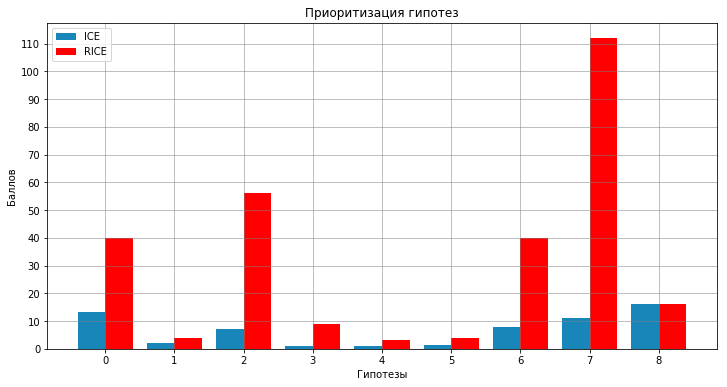

```python
plt.figure(figsize=(12, 6))
ax = plt.subplot()
offset = 0.2
n_ticks = np.arange(len(hypothesis['ice']))
plt.bar(n_ticks - offset, hypothesis['ice'], width=0.4, color='#1986BA')
plt.bar(n_ticks + offset, hypothesis['rice'], width=0.4, color='#FF0000')

ax.xaxis.set_major_locator(MultipleLocator(base=1))
ax.yaxis.set_major_locator(MultipleLocator(base=10))
plt.grid(which='major', color='grey', linewidth=0.5)
plt.legend(['ICE', 'RICE'], loc='upper left')
plt.title('Приоритизация гипотез')
plt.xlabel('Гипотезы')
plt.ylabel('Баллов')

plt.show()
```

**Промежуточные выводы:**

- проведена приоритизация гипотез по ICE и RICE;
- согласно фреймворка ICE наиболее приоритетной гипотезой является: `Запустить акцию, дающую скидку на товар в день рождения`;
- согласно фреймворка RICE наиболее приоритетной гипотезой является: `Добавить форму подписки на все основные страницы, чтобы собрать базу клиентов для email-рассылок`.

## Часть 2. Анализ A/B-теста.

```python
orders.head()
```

|  | transactionId | visitorId | date | revenue | group |
| --- | --- | --- | --- | --- | --- |
| 0 | 3667963787 | 3312258926 | 2019-08-15 | 1650 | B |
| 1 | 2804400009 | 3642806036 | 2019-08-15 | 730 | B |
| 2 | 2961555356 | 4069496402 | 2019-08-15 | 400 | A |
| 3 | 3797467345 | 1196621759 | 2019-08-15 | 9759 | B |
| 4 | 2282983706 | 2322279887 | 2019-08-15 | 2308 | B |

```python
orders.info()
```

```
<class 'pandas.core.frame.DataFrame'>
RangeIndex: 1197 entries, 0 to 1196
Data columns (total 5 columns):
 #   Column         Non-Null Count  Dtype
---  ------         --------------  -----
 0   transactionId  1197 non-null   int64
 1   visitorId      1197 non-null   int64
 2   date           1197 non-null   object
 3   revenue        1197 non-null   int64
 4   group          1197 non-null   object
dtypes: int64(3), object(2)
memory usage: 46.9+ KB
```

```python
orders.duplicated().sum()
```

```
0
```

```python
orders['transactionId'].nunique()
```

```
1197
```

```python
orders['visitorId'].nunique()
```

```
1031
```

```python
orders['date'] = orders['date'].map(lambda x: dt.datetime.strptime(x, '%Y-%m-%d'))
```

```python
print('Данные в диапазоне:', orders['date'].min(), '--', orders['date'].max())
```

```
Данные в диапазоне: 2019-08-01 00:00:00 -- 2019-08-31 00:00:00
```

```python
orders['revenue'].describe()
```

```
count    1.197000e+03
mean     8.348006e+03
std      3.919113e+04
min      5.000000e+01
25%      1.220000e+03
50%      2.978000e+03
75%      8.290000e+03
max      1.294500e+06
Name: revenue, dtype: float64
```

```python
orders['group'].unique()
```

```
array(['B', 'A'], dtype=object)
```

```python
visitors = pd.read_csv('visitors.csv', sep=',')
```

```python
visitors.head()
```

|  | date | group | visitors |
| --- | --- | --- | --- |
| 0 | 2019-08-01 | A | 719 |
| 1 | 2019-08-02 | A | 619 |
| 2 | 2019-08-03 | A | 507 |
| 3 | 2019-08-04 | A | 717 |
| 4 | 2019-08-05 | A | 756 |

```python
visitors.info()
```

```
<class 'pandas.core.frame.DataFrame'>
RangeIndex: 62 entries, 0 to 61
Data columns (total 3 columns):
 #   Column    Non-Null Count  Dtype
---  ------    --------------  -----
 0   date      62 non-null     object
 1   group     62 non-null     object
 2   visitors  62 non-null     int64
dtypes: int64(1), object(2)
memory usage: 1.6+ KB
```

```python
visitors.duplicated().sum()
```

```
0
```

```python
visitors['date'] = visitors['date'].map(lambda x: dt.datetime.strptime(x, '%Y-%m-%d'))
```

```python
print('Данные в диапазоне:', visitors['date'].min(), '--', visitors['date'].max())
```

```
Данные в диапазоне: 2019-08-01 00:00:00 -- 2019-08-31 00:00:00
```

```python
visitors['group'].unique()
```

```
array(['A', 'B'], dtype=object)
```

```python
visitors['visitors'].describe()
```

```
count     62.000000
mean     607.290323
std      114.400560
min      361.000000
25%      534.000000
50%      624.500000
75%      710.500000
max      770.000000
Name: visitors, dtype: float64
```

**Промежуточные выводы:**

- изучены данные о посетителях сайта магазина и заказах;
- в целом данные корректны, готовы к дальнейшему использованию;
- данные соответствуют описанию;
- изменили форматы данных о датах.

### Исследование, имитирующее A/A-тест.

Проверили выполнение следующих условий.

1. Количество пользователей в различных группах различается не более, чем на 1%.

```python
orders_in_group = orders.groupby('group', as_index=False).agg(visitors=('visitorId', 'nunique'))
orders_in_group
```

|  | group | visitors |
| --- | --- | --- |
| 0 | A | 503 |
| 1 | B | 586 |

```python
print('Количество пользователей в группах покупателей различается на {:.2%}'.\
      format(abs(1 - orders_in_group.loc[0, 'visitors'] / orders_in_group.loc[1, 'visitors'])))
```

```
Количество пользователей в группах покупателей различается на 14.16%
```

```python
visitors_in_group = visitors.groupby('group', as_index=False).agg({'visitors': 'nunique'})
visitors_in_group
```

|  | group | visitors |
| --- | --- | --- |
| 0 | A | 31 |
| 1 | B | 30 |

```python
print('Количество пользователей в группах посетителей различается на {:.2%}'.\
      format(abs(1 - visitors_in_group.loc[0, 'visitors'] / visitors_in_group.loc[1, 'visitors'])))
```

```
Количество пользователей в группах посетителей различается на 3.33%
```

1. Для всех групп фиксируют и отправляют в системы аналитики данные об одном и том же.

Да.

1. Различие ключевых метрик по группам не превышает 1% и не имеет статистической значимости.

Стат. значимость не проверяли.

1. Попавший в одну из групп посетитель остаётся в этой группе до конца теста.

```python
A_users = orders.query('group == "A"')['visitorId'].unique()
```

```python
AB_users = orders.query('(group == "B") and (visitorId in @A_users)')['visitorId'].unique()
```

```python
print('Доля дублирующих пользователей от всех уникальных {:.2%}'.format(len(AB_users) / orders['visitorId'].nunique()))
print('Доля дублирующих пользователей от выборки {:.2%}'.format(len(AB_users) / orders.shape[0]))
```

```
Доля дублирующих пользователей от всех уникальных 5.63%
Доля дублирующих пользователей от выборки 4.85%
```

Исследование должно быть на этом этапе прекращено и проведено с начала.

Однако для нужд настоящего проекта не учитывали дублирующих пользователей.

**Здесь и далее в качестве фрейма с данными о заказах применяли `orders_uniq`.**

```python
orders_uniq = orders.query('visitorId not in @AB_users')
orders_uniq.info()
```

```
<class 'pandas.core.frame.DataFrame'>
Int64Index: 1016 entries, 0 to 1196
Data columns (total 5 columns):
 #   Column         Non-Null Count  Dtype
---  ------         --------------  -----
 0   transactionId  1016 non-null   int64
 1   visitorId      1016 non-null   int64
 2   date           1016 non-null   datetime64[ns]
 3   revenue        1016 non-null   int64
 4   group          1016 non-null   object
dtypes: datetime64[ns](1), int64(3), object(1)
memory usage: 47.6+ KB
```

**Промежуточные выводы:**

- провели исследование, имитирующее A/A-тест;
- установили, что не все необходимые для A/B-теста условия выполнены;
- исправили недостатки удалением дублирующих пользователей, их оказалось около 5 %.

### Графики кумулятивной выручки по группам.

```python
orders_uniq.head()
```

|  | transactionId | visitorId | date | revenue | group |
| --- | --- | --- | --- | --- | --- |
| 0 | 3667963787 | 3312258926 | 2019-08-15 | 1650 | B |
| 1 | 2804400009 | 3642806036 | 2019-08-15 | 730 | B |
| 3 | 3797467345 | 1196621759 | 2019-08-15 | 9759 | B |
| 4 | 2282983706 | 2322279887 | 2019-08-15 | 2308 | B |
| 5 | 182168103 | 935554773 | 2019-08-15 | 2210 | B |

**Для клиентов из группы A:**

```python
orders_A_dayly = orders_uniq.query('group == "A"').\
groupby('date', as_index=False).\
agg(day_orders=('transactionId', 'nunique'), day_revenue=('revenue', 'sum'))
```

```python
orders_A_cumm = orders_A_dayly.apply(lambda x: orders_A_dayly[orders_A_dayly['date'] <= x['date']].\
                                     agg({'date': 'max', 'day_orders': 'sum', 'day_revenue': 'sum'}), axis=1).\
sort_values(by='date')
orders_A_cumm.columns = ['date', 'day_orders_cumm', 'day_revenue_cumm']
orders_A_cumm.head()
```

|  | date | day_orders_cumm | day_revenue_cumm |
| --- | --- | --- | --- |
| 0 | 2019-08-01 | 23 | 142779 |
| 1 | 2019-08-02 | 42 | 234381 |
| 2 | 2019-08-03 | 66 | 346854 |
| 3 | 2019-08-04 | 77 | 388030 |
| 4 | 2019-08-05 | 99 | 474413 |

**Для клиентов из группы B:**

```python
orders_B_dayly = orders_uniq.query('group == "B"').\
groupby('date', as_index=False).\
agg(day_orders=('transactionId', 'nunique'), day_revenue=('revenue', 'sum'))
```

```python
orders_B_cumm = orders_B_dayly.apply(lambda x: orders_B_dayly[orders_B_dayly['date'] <= x['date']].\
                                     agg({'date': 'max', 'day_orders': 'sum', 'day_revenue': 'sum'}), axis=1).\
sort_values(by='date')
orders_B_cumm.columns = ['date', 'day_orders_cumm', 'day_revenue_cumm']
orders_B_cumm.head()
```

|  | date | day_orders_cumm | day_revenue_cumm |
| --- | --- | --- | --- |
| 0 | 2019-08-01 | 17 | 59758 |
| 1 | 2019-08-02 | 40 | 221801 |
| 2 | 2019-08-03 | 54 | 288850 |
| 3 | 2019-08-04 | 68 | 385740 |
| 4 | 2019-08-05 | 89 | 475648 |

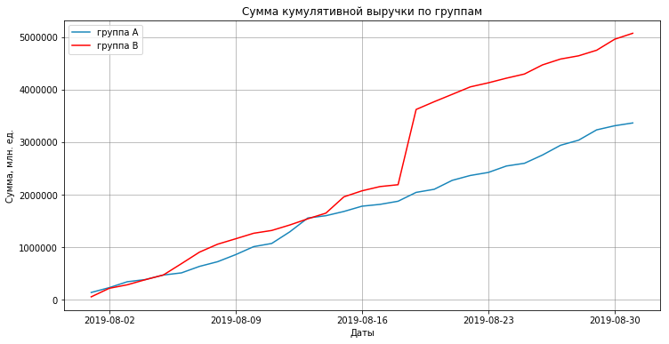

```python
plt.figure(figsize=(12, 6))

plt.plot(orders_A_cumm['date'], orders_A_cumm['day_revenue_cumm'], label=('A'), color='#1986BA')
plt.plot(orders_B_cumm['date'], orders_B_cumm['day_revenue_cumm'], label=('B'), color='#FF0000')
plt.grid(which='major', color='grey', linewidth=0.5)
plt.legend(['группа A', 'группа B'], loc='upper left')
plt.title('Сумма кумулятивной выручки по группам')
plt.xlabel('Даты')
plt.ylabel('Сумма, млн. ед.')

plt.show()
```

Справочно привели графики динамики кумулятивного количества заказов по группам:

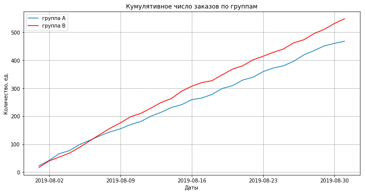

```python
plt.figure(figsize=(12, 6))

plt.plot(orders_A_cumm['date'], orders_A_cumm['day_orders_cumm'], label=('A'), color='#1986BA')
plt.plot(orders_B_cumm['date'], orders_B_cumm['day_orders_cumm'], label=('B'), color='#FF0000')
plt.grid(which='major', color='grey', linewidth=0.5)
plt.legend(['группа A', 'группа B'], loc='upper left')
plt.title('Кумулятивное число заказов по группам')
plt.xlabel('Даты')
plt.ylabel('Количество, ед.')

plt.show()
```

**Промежуточные выводы:**

- примерно до середины периода исследования кумулятивные выручки по группам росли синхронно;
- затем наблюдали резкий скачок суммы по группе B; вероятно, он стал следствием крупного заказа или заказов;
- кумулятивный показатель общего количества заказов при этом резко не менялся;
- по накопленному количеству стабильно лучше группа B.

### Графики кумулятивного среднего чека по группам.

```python
orders_A_cumm['avg_revenue_cumm'] = orders_A_cumm['day_revenue_cumm'] / orders_A_cumm['day_orders_cumm']
orders_B_cumm['avg_revenue_cumm'] = orders_B_cumm['day_revenue_cumm'] / orders_B_cumm['day_orders_cumm']
```

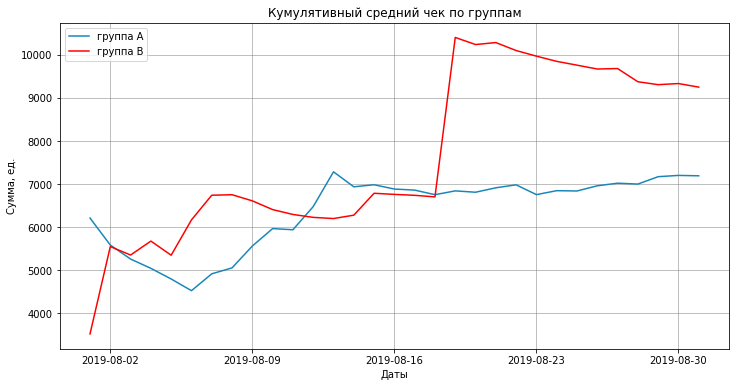

```python
plt.figure(figsize=(12, 6))

plt.plot(orders_A_cumm['date'], orders_A_cumm['avg_revenue_cumm'], label=('A'), color='#1986BA')
plt.plot(orders_B_cumm['date'], orders_B_cumm['avg_revenue_cumm'], label=('B'), color='#FF0000')
plt.grid(which='major', color='grey', linewidth=0.5)
plt.legend(['группа A', 'группа B'], loc='upper left')
plt.title('Кумулятивный средний чек по группам')
plt.xlabel('Даты')
plt.ylabel('Сумма, ед.')

plt.show()
```

**Промежуточные выводы:**

- наблюдали скачок кумулятивного среднего по группе B;
- как и в случае с кумулятивной выручкой он, вероятно, стал следствием крупного заказа или заказов;
- к концу периода исследования показатели стабилизировались;
- показатель по группе B к концу исследования стабильно лучше группы A.

### График относительного изменения кумулятивного среднего чека группы B к группе A.

```python
orders_A_B_cumm = orders_A_cumm.merge(orders_B_cumm, on='date', how='left', suffixes=['A', 'B'])
```

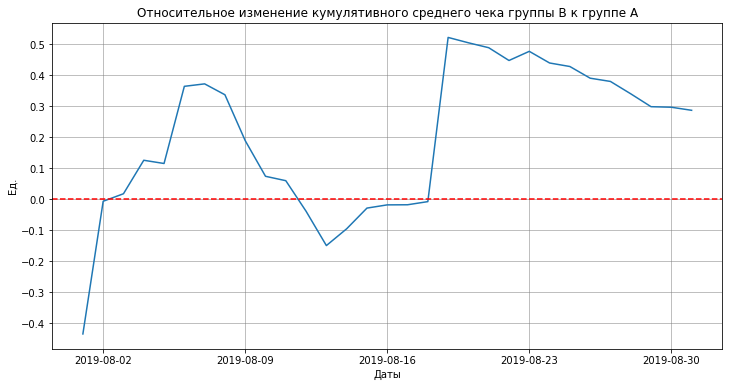

```python
plt.figure(figsize=(12, 6))
ax = plt.subplot()

plt.plot(orders_A_B_cumm['date'], orders_A_B_cumm['avg_revenue_cummB'] / orders_A_B_cumm['avg_revenue_cummA'] - 1)
plt.axhline(y=0, color='red', linestyle='--')

ax.yaxis.set_major_locator(MultipleLocator(base=0.1))
plt.grid(which='major', color='grey', linewidth=0.5)
plt.title('Относительное изменение кумулятивного среднего чека группы B к группе A')
plt.xlabel('Даты')
plt.ylabel('Ед.')

plt.show()
```

**Промежуточные выводы:**

- относительное значение существенно колебалось в течение периода исследования;
- вновь наблюдали скачок значений по группе B;
- к концу периода показатель по группе B стабильно лучше показателя по группе A.

### Графики кумулятивного среднего количества заказов на посетителя по группам.

**Для группы A.**

```python
visitors_A_dayly = visitors.query('group == "A"')
```

```python
visitors_A_cumm = visitors_A_dayly.apply(lambda x: visitors_A_dayly[visitors_A_dayly['date'] <= x['date']].\
                                     agg({'date': 'max', 'visitors': 'sum'}), axis=1).\
sort_values(by='date')
visitors_A_cumm.columns = ['date', 'day_visitors_cumm']
visitors_A_cumm.head()
```

|  | date | day_visitors_cumm |
| --- | --- | --- |
| 0 | 2019-08-01 | 719 |
| 1 | 2019-08-02 | 1338 |
| 2 | 2019-08-03 | 1845 |
| 3 | 2019-08-04 | 2562 |
| 4 | 2019-08-05 | 3318 |

```python
orders_per_visitor_A_cumm = orders_A_cumm.merge(visitors_A_cumm, on='date', how='left')
orders_per_visitor_A_cumm['avg_orders_cumm'] =\
orders_per_visitor_A_cumm['day_orders_cumm'] / orders_per_visitor_A_cumm['day_visitors_cumm']
```

**Для группы B.**

```python
visitors_B_dayly = visitors.query('group == "B"')
```

```python
visitors_B_cumm = visitors_B_dayly.apply(lambda x: visitors_B_dayly[visitors_B_dayly['date'] <= x['date']].\
                                     agg({'date': 'max', 'visitors': 'sum'}), axis=1).\
sort_values(by='date')
visitors_B_cumm.columns = ['date', 'day_visitors_cumm']
visitors_B_cumm.head()
```

|  | date | day_visitors_cumm |
| --- | --- | --- |
| 31 | 2019-08-01 | 713 |
| 32 | 2019-08-02 | 1294 |
| 33 | 2019-08-03 | 1803 |
| 34 | 2019-08-04 | 2573 |
| 35 | 2019-08-05 | 3280 |

```python
orders_per_visitor_B_cumm = orders_B_cumm.merge(visitors_B_cumm, on='date', how='left')
orders_per_visitor_B_cumm['avg_orders_cumm'] =\
orders_per_visitor_B_cumm['day_orders_cumm'] / orders_per_visitor_B_cumm['day_visitors_cumm']
```

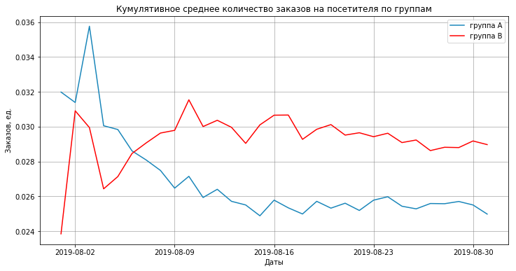

```python
plt.figure(figsize=(12, 6))

plt.plot(orders_per_visitor_A_cumm['date'], orders_per_visitor_A_cumm['avg_orders_cumm'], label=('A'), color='#1986BA')
plt.plot(orders_per_visitor_B_cumm['date'], orders_per_visitor_B_cumm['avg_orders_cumm'], label=('B'), color='#FF0000')
plt.grid(which='major', color='grey', linewidth=0.5)
plt.legend(['группа A', 'группа B'], loc='upper right')
plt.title('Кумулятивное среднее количество заказов на посетителя по группам')
plt.xlabel('Даты')
plt.ylabel('Заказов, ед.')

plt.show()
```

**Промежуточные выводы:**

- наблюдали колебания показателей по обеим группам, затухающие к конку периода;
- показатели по группе B стабильно лучше, чем по группе A.

### График относительного изменения кумулятивного среднего количества заказов на посетителя группы B к группе A.

```python
orders_per_visitor_A_B_cumm =\
orders_per_visitor_A_cumm.merge(orders_per_visitor_B_cumm, on='date', how='left', suffixes=['A', 'B'])
```

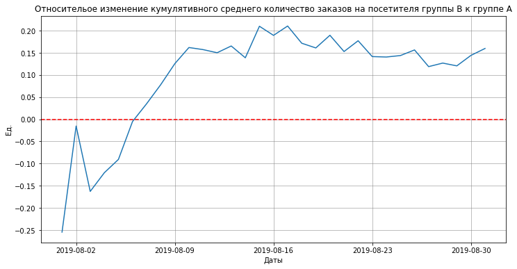

```python
plt.figure(figsize=(12, 6))
ax = plt.subplot()

plt.plot(orders_per_visitor_A_B_cumm['date'], orders_per_visitor_A_B_cumm['avg_orders_cummB'] /
         orders_per_visitor_A_B_cumm['avg_orders_cummA'] - 1)
plt.axhline(y=0, color='red', linestyle='--')

ax.yaxis.set_major_locator(MultipleLocator(base=0.05))
plt.grid(which='major', color='grey', linewidth=0.5)
plt.title('Относительое изменение кумулятивного среднего количество заказов на посетителя группы B к группе A')
plt.xlabel('Даты')
plt.ylabel('Ед.')

plt.show()
```

**Промежуточные выводы:**

- наблюдали картину, соответствующую наблюдениям предыдущего пункта;
- относительный показатель по B почти сразу вышел в зону " > 0 " и не покинул её до конца периода;
- к концу периода обозначился рост относительного показателя.

### Точечный график количества заказов по пользователям.

```python
orders_by_users = orders_uniq.groupby('visitorId', as_index=False).agg({'transactionId': 'nunique'})
orders_by_users.columns = ['user_id', 'orders_by_user']
```

```python
orders_by_users.sort_values(by='orders_by_user', ascending=False).head()
```

|  | user_id | orders_by_user |
| --- | --- | --- |
| 908 | 3967698036 | 3 |
| 55 | 249864742 | 3 |
| 478 | 2108163459 | 3 |
| 687 | 2988190573 | 3 |
| 890 | 3908431265 | 3 |

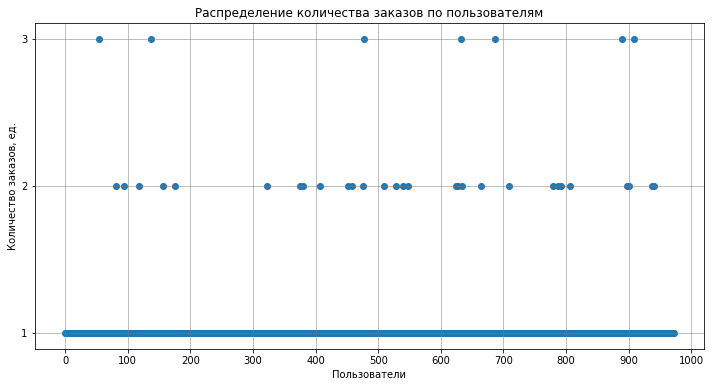

```python
plt.figure(figsize=(12, 6))
ax = plt.subplot()

x_values = pd.Series(range(0,len(orders_by_users)))
plt.scatter(x_values, orders_by_users['orders_by_user'])

ax.yaxis.set_major_locator(MultipleLocator(base=1))
ax.xaxis.set_major_locator(MultipleLocator(base=100))
plt.grid(which='major', color='grey', linewidth=0.5)
plt.title('Распределение количества заказов по пользователям')
plt.xlabel('Пользователи')
plt.ylabel('Количество заказов, ед.')

plt.show()
```

### Расчёт перцентилей количества заказов.

Рассчитали 90-й, 95-й и 99-й перцентили количества заказов на пользователя.

```python
print(np.percentile(orders_by_users['orders_by_user'], [90, 95, 99]))
```

```
[1. 1. 2.]
```

Граница для определения аномальных пользователей:

использовать данные о пользователях **не более чем с 2-мя заказами**.

### Точечный график стоимостей заказов.

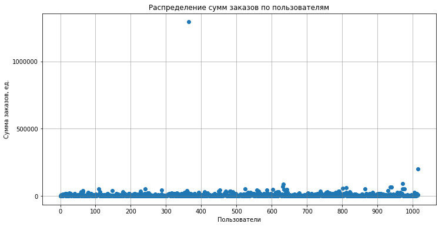

```python
plt.figure(figsize=(12, 6))
ax = plt.subplot()

x_values = pd.Series(range(0,len(orders_uniq)))
plt.scatter(x_values, orders_uniq['revenue'])

ax.yaxis.set_major_locator(MultipleLocator(base=500000))
ax.xaxis.set_major_locator(MultipleLocator(base=100))
plt.grid(which='major', color='grey', linewidth=0.5)
plt.title('Распределение сумм заказов по пользователям')
plt.xlabel('Пользователи')
plt.ylabel('Сумма заказов, ед.')

plt.show()
```

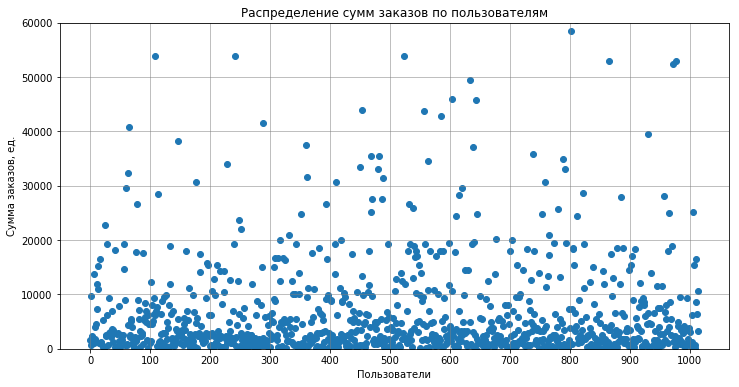

```python
plt.figure(figsize=(12, 6))
ax = plt.subplot()

x_values = pd.Series(range(0,len(orders_uniq)))
plt.scatter(x_values, orders_uniq['revenue'])
ax.set_ylim(0, 60000)

ax.yaxis.set_major_locator(MultipleLocator(base=10000))
ax.xaxis.set_major_locator(MultipleLocator(base=100))
plt.grid(which='major', color='grey', linewidth=0.5)
plt.title('Распределение сумм заказов по пользователям')
plt.xlabel('Пользователи')
plt.ylabel('Сумма заказов, ед.')

plt.show()
```

### Расчёт перцентилей сумм заказов.

```python
print(np.percentile(orders_uniq['revenue'], [90, 95, 99]))
```

```
[17990. 26785. 53904.]
```

Граница для определения аномальных пользователей:

использовать данные о пользователях **с суммой заказа на более 27 000**.

**Промежуточные выводы:**

- данные о количестве заказов имеют малое число аномально высоких значений;
- данные о суммах заказов разбросаны сильнее;
- в дальнейшем стоит учесть необходимость "очистить" данные и о количестве заказов, и об их суммах.

### Расчёт статистической значимости различий в среднем количестве заказов на посетителя между группами по «сырым» данным.

```python
orders_by_users_A = orders_uniq.query('group == "A"').\
groupby('visitorId', as_index=False).agg({'transactionId': 'nunique'})
orders_by_users_A.columns = ['user_id', 'orders_by_user']
```

```python
orders_by_users_B = orders_uniq.query('group == "B"').\
groupby('visitorId', as_index=False).agg({'transactionId': 'nunique'})
orders_by_users_B.columns = ['user_id', 'orders_by_user']
```

```python
pd.Series(0, index=np.arange(visitors_A_dayly['visitors'].sum() - len(orders_by_users_A['orders_by_user'])), name='orders')
pd.Series(0, index=np.arange(visitors_B_dayly['visitors'].sum() - len(orders_by_users_B['orders_by_user'])), name='orders')
```

```
0        0
1        0
2        0
3        0
4        0
        ..
18383    0
18384    0
18385    0
18386    0
18387    0
Name: orders, Length: 18388, dtype: int64
```

```python
sampleA = pd.concat([orders_by_users_A['orders_by_user'],\
                     pd.Series(0, index=np.arange(visitors_A_dayly['visitors'].sum() - len(orders_by_users_A['orders_by_user'])), name='orders')], axis=0)
sampleB = pd.concat([orders_by_users_B['orders_by_user'],\
                     pd.Series(0, index=np.arange(visitors_B_dayly['visitors'].sum() - len(orders_by_users_B['orders_by_user'])), name='orders')], axis=0)
```

**Выдвинули нулевую и альтернативную гипотезы:**

H_0: Статистически значимых различий в среднем количестве заказов на посетителя между группами нет.

H_a: Статистически значимые различия в среднем количестве заказов на посетителя между группами есть.

Пороговое значение alpha = 0.05. Это приемлемый уровень достоверности.

```python
alpha = 0.05

print("{0:.5f}".format(stats.mannwhitneyu(sampleA, sampleB)[1]))

if stats.mannwhitneyu(sampleA, sampleB)[1] < alpha:
    print('Отвергаем нулевую гипотезу')
else:
    print('Не получилось отвергнуть нулевую гипотезу')

print("Относительный прирост среднего числа заказов группы B: {0:.5f}".format(sampleB.mean() / sampleA.mean() - 1))
```

```
0.00551
Отвергаем нулевую гипотезу
Относительный прирост среднего числа заказов группы B: 0.15980
```

### Расчёт статистической значимости различий в среднем чеке заказа между группами по «сырым» данным.

**Выдвинули нулевую и альтернативную гипотезы:**

H_0: Статистически значимых различий в среднем чеке между группами нет.

H_a: Статистически значимые различия в среднем чеке между группами есть.

Пороговое значение alpha = 0.05. Это приемлемый уровень достоверности.

```python
alpha = 0.05

print("{0:.5f}".format(stats.mannwhitneyu(orders_uniq.query('group == "A"')['revenue'],\
                                          orders_uniq.query('group == "B"')['revenue'])[1]))

if stats.mannwhitneyu(orders_uniq.query('group == "A"')['revenue'],\
                      orders_uniq.query('group == "B"')['revenue'])[1] < alpha:
    print('Отвергаем нулевую гипотезу')
else:
    print('Не получилось отвергнуть нулевую гипотезу')

print("Относительный прирост среднего чека группы B: {0:.5f}".\
      format(orders_uniq.query('group == "B"')['revenue'].mean() / orders_uniq.query('group == "A"')['revenue'].mean() - 1))
```

```
0.41475
Не получилось отвергнуть нулевую гипотезу
Относительный прирост среднего чека группы B: 0.28660
```

**Промежуточные выводы:**

- хотя средний чек по группе B и выше, однако стат. значимость зафиксирована только в отношении отличий среднего количества заказов;
- вероятно, это вызвано следующим: посетители стали покупать чаще, а средний чек увеличился лишь за счёт отдельных, экстремальных значений.

### Расчёт статистической значимости различий в среднем количестве заказов на посетителя между группами по «очищенным» данным.

Удалили из расчётов пользователей, которые сделали более 2 заказов и(или) заказы на сумму более 27 000.

```python
orders_percentile = np.percentile(orders_by_users['orders_by_user'], [99]).astype('float')[0]
revenue_percentile = np.percentile(orders_uniq['revenue'], [95]).astype('float')[0]
```

```python
many_orders_users = orders_by_users.query('orders_by_user > @orders_percentile')['user_id']
expensive_orders_users = orders_uniq.query('revenue > @revenue_percentile')['visitorId']
abnormal_users = (pd.concat([many_orders_users, expensive_orders_users], axis=0).drop_duplicates())
```

```python
abnormal_users.head()
```

```
55      249864742
138     611059232
478    2108163459
632    2742574263
687    2988190573
dtype: int64
```

```python
abnormal_users.shape
```

```
(58,)
```

Повторили расчёты, исключив пользователей из abnormal_users.

Здесь и далее в расчётах по "очищенным" данным переменные назвали как `_clean`.

```python
orders_by_users_A_clean = orders_uniq.query('group == "A" and visitorId not in @abnormal_users').\
groupby('visitorId', as_index=False).agg({'transactionId': 'nunique'})
orders_by_users_A_clean.columns = ['user_id', 'orders_by_user']
```

```python
orders_by_users_B_clean = orders_uniq.query('group == "B" and visitorId not in @abnormal_users').\
groupby('visitorId', as_index=False).agg({'transactionId': 'nunique'})
orders_by_users_B_clean.columns = ['user_id', 'orders_by_user']
```

```python
sampleA_clean = pd.concat([orders_by_users_A_clean['orders_by_user'],\
                     pd.Series(0, index=np.arange(visitors_A_dayly['visitors'].sum() - len(orders_by_users_A['orders_by_user'])), name='orders')], axis=0)
sampleB_clean = pd.concat([orders_by_users_B_clean['orders_by_user'],\
                     pd.Series(0, index=np.arange(visitors_B_dayly['visitors'].sum() - len(orders_by_users_B['orders_by_user'])), name='orders')], axis=0)
```

Выдвинули нулевую и альтернативную гипотезы:

H_0: Статистически значимых различий в среднем количестве заказов на посетителя между группами (очищенные данные) нет.

H_a: Статистически значимые различия в среднем количестве заказов на посетителя между группами (очищенные данные) есть.

Пороговое значение alpha = 0.05. Это приемлемый уровень достоверности.

```python
alpha = 0.05

print("{0:.5f}".format(stats.mannwhitneyu(sampleA_clean, sampleB_clean)[1]))

if stats.mannwhitneyu(sampleA_clean, sampleB_clean)[1] < alpha:
    print('Отвергаем нулевую гипотезу')
else:
    print('Не получилось отвергнуть нулевую гипотезу')

print("Относительный прирост среднего числа заказов группы B: {0:.5f}".format(sampleB_clean.mean() / sampleA_clean.mean() - 1))
```

```
0.00618
Отвергаем нулевую гипотезу
Относительный прирост среднего числа заказов группы B: 0.18190
```

### Расчёт статистической значимости различий в среднем чеке заказа между группами по «очищенным» данным.

```python
orders_uniq_clean = orders_uniq.query('visitorId not in @abnormal_users')
```

**Выдвинули нулевую и альтернативную гипотезы:**

H_0: Статистически значимых различий в среднем чеке между группами (очищенные данные) нет.

H_a: Статистически значимые различия в среднем чеке между группами (очищенные данные) есть.

Пороговое значение alpha = 0.05. Это приемлемый уровень достоверности.

```python
alpha = 0.05

print("{0:.5f}".format(stats.mannwhitneyu(orders_uniq_clean.query('group == "A"')['revenue'],\
                                          orders_uniq_clean.query('group == "B"')['revenue'])[1]))

if stats.mannwhitneyu(orders_uniq_clean.query('group == "A"')['revenue'],\
                      orders_uniq_clean.query('group == "B"')['revenue'])[1] < alpha:
    print('Отвергаем нулевую гипотезу')
else:
    print('Не получилось отвергнуть нулевую гипотезу')

print("Относительный прирост среднего чека группы B: {0:.5f}".\
      format(orders_uniq_clean.query('group == "B"')['revenue'].mean() / orders_uniq_clean.query('group == "A"')['revenue'].mean() - 1))
```

```
0.32295
Не получилось отвергнуть нулевую гипотезу
Относительный прирост среднего чека группы B: -0.04847
```

**Справочно воспроизвели расчёты на "очищенных" данных, перестроили некоторые графики.**

```python
orders_A_dayly_clean = orders_uniq_clean.query('group == "A"').\
groupby('date', as_index=False).\
agg(day_orders=('transactionId', 'nunique'), day_revenue=('revenue', 'sum'))
orders_A_cumm_clean = orders_A_dayly_clean.apply(lambda x: orders_A_dayly_clean[orders_A_dayly_clean['date'] <= x['date']].\
                                     agg({'date': 'max', 'day_orders': 'sum', 'day_revenue': 'sum'}), axis=1).\
sort_values(by='date')
orders_A_cumm_clean.columns = ['date', 'day_orders_cumm', 'day_revenue_cumm']
orders_B_dayly_clean = orders_uniq_clean.query('group == "B"').\
groupby('date', as_index=False).\
agg(day_orders=('transactionId', 'nunique'), day_revenue=('revenue', 'sum'))
orders_B_cumm_clean = orders_B_dayly_clean.apply(lambda x: orders_B_dayly_clean[orders_B_dayly_clean['date'] <= x['date']].\
                                     agg({'date': 'max', 'day_orders': 'sum', 'day_revenue': 'sum'}), axis=1).\
sort_values(by='date')
orders_B_cumm_clean.columns = ['date', 'day_orders_cumm', 'day_revenue_cumm']

orders_A_cumm_clean['avg_revenue_cumm'] = orders_A_cumm_clean['day_revenue_cumm'] / orders_A_cumm_clean['day_orders_cumm']
orders_B_cumm_clean['avg_revenue_cumm'] = orders_B_cumm_clean['day_revenue_cumm'] / orders_B_cumm_clean['day_orders_cumm']
```

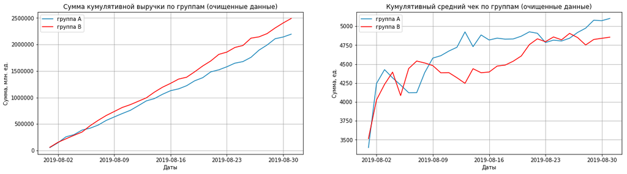

```python
plt.figure(figsize=(20, 5))

ax1 = plt.subplot(1, 2, 1)
ax1.plot(orders_A_cumm_clean['date'], orders_A_cumm_clean['day_revenue_cumm'], label=('A'), color='#1986BA')
ax1.plot(orders_B_cumm_clean['date'], orders_B_cumm_clean['day_revenue_cumm'], label=('B'), color='#FF0000')
ax1.grid(which='major', color='grey', linewidth=0.5)
ax1.legend(['группа A', 'группа B'], loc='upper left')
ax1.set_title('Сумма кумулятивной выручки по группам (очищенные данные)')
ax1.set_xlabel('Даты')
ax1.set_ylabel('Сумма, млн. ед.')

ax2 = plt.subplot(1, 2, 2)
ax2.plot(orders_A_cumm_clean['date'], orders_A_cumm_clean['avg_revenue_cumm'], label=('A'), color='#1986BA')
ax2.plot(orders_B_cumm_clean['date'], orders_B_cumm_clean['avg_revenue_cumm'], label=('B'), color='#FF0000')
ax2.grid(which='major', color='grey', linewidth=0.5)
ax2.legend(['группа A', 'группа B'], loc='upper left')
ax2.set_title('Кумулятивный средний чек по группам (очищенные данные)')
ax2.set_xlabel('Даты')
ax2.set_ylabel('Сумма, ед.')

plt.show()
```

**Промежуточные выводы:**

- результаты по "очищенным" данным в целом аналогичны результатам на "сырых" данных;
- стат. значимость зафиксирована только в отношении отличий среднего количества заказов;
- однако при этом зафиксировано снижение среднего чека группы B на почти 5 %: из исследования исключили крупные заказы, и показатель группы B ухудшился;
- показатели среднего чека на "чистых" данных почти до конца исследования вели себя нестабильно; они не показывают явного превосходства одной из групп; скорее можно сказать, что группа B не смогла на этом показателе "победить" A.

### Решение по результатам теста.

Приняли решение по результатам теста: остановить тест, зафиксировать победу группы B, хотя и не абсолютную.

## Общие выводы.

1. Изучили исходные данные о гипотезах.
2. Данные соответствуют описанию, готовы для исследования.
3. Проведена приоритизация гипотез по ICE и RICE.
4. Согласно фреймворка ICE наиболее приоритетной гипотезой является: `Запустить акцию, дающую скидку на товар в день рождения`.
5. Согласно фреймворка RICE наиболее приоритетной гипотезой является: `Добавить форму подписки на все основные страницы, чтобы собрать базу клиентов для email-рассылок`.
6. Изучены данные о посетителях сайта магазина и заказах.
7. В целом данные корректны, готовы к дальнейшему использованию, данные соответствуют описанию.
8. Изменили форматы данных о датах.
9. Провели исследование, имитирующее A/A-тест.
10. Установили, что не все необходимые для A/B-теста условия выполнены.
11. Исправили недостатки удалением дублирующих пользователей: их оказалось около 5 %.
12. По изучении графиков установили:
13. примерно до середины периода исследования кумулятивные выручки по группам росли синхронно;
14. затем наблюдали резкий скачок суммы по группе B; вероятно, он стал следствием крупного заказа или заказов;
15. кумулятивный показатель общего количества заказов при этом резко не менялся;
16. по накопленному количеству стабильно лучше группа B;
17. наблюдали скачок кумулятивного среднего по группе B;
18. как и в случае с кумулятивной выручкой он, вероятно, стал следствием крупного заказа или заказов;
19. к концу периода исследования показатели стабилизировались;
20. показатель по группе B к концу исследования стабильно лучше группы A;
21. относительное значение существенно колебалось в течение периода исследования;
22. вновь наблюдали скачок значений по группе B;
23. к концу периода показатель по группе B стабильно лучше показателя по группе A;
24. наблюдали колебания показателей по обеим группам, затухающие к конку периода;
25. показатели по группе B стабильно лучше, чем по группе A;
26. относительный показатель по B почти сразу вышел в зону " > 0 " и не покинул её до конца периода;
27. к концу периода обозначился рост относительного показателя.
28. Данные о количестве заказов имеют малое число аномально высоких значений.
29. Данные о суммах заказов разбросаны сильнее.
30. В дальнейшем стоит учесть необходимость "очистить" данные и о количестве заказов, и об их суммах.
31. Хотя средний чек по группе B и выше, однако стат. значимость зафиксирована только в отношении отличий среднего количества заказов.
32. Вероятно, это вызвано следующим: посетители стали покупать чаще, а средний чек увеличился лишь за счёт отдельных, экстремальных значений.
33. Результаты по "очищенным" данным в целом аналогичны результатам на "сырых" данных.
34. Стат. значимость зафиксирована только в отношении отличий среднего количества заказов.
35. Однако при этом зафиксировано снижение среднего чека группы B на почти 5 %: из исследования исключили крупные заказы, и показатель группы B ухудшился.
36. Показатели среднего чека на "чистых" данных почти до конца исследования вели себя нестабильно; они не показывают явного превосходства одной из групп; скорее можно сказать, что группа B не смогла на этом показателе "победить" A.
37. Приняли решение по результатам теста: остановить тест, зафиксировать победу группы B, хотя и не абсолютную.